# Classification

## Where we left off

- **Day 10:** linear regression predicts a **number** (mpg, sales).
  - Judged by MSE: how far off, on average, squared
- Many questions have a **category** as the answer instead.
  - Will this customer default? Yes or No
  - Which brand will this shopper buy?
- **Today: classification.**
  - Why linear regression is the wrong tool
  - How to score a classifier (MSE no longer works)

## 1. A new kind of Y

## Classification problems

When \(Y\) is a category, predicting it is **classification**. The categories are called **classes**.

| Question | Y | Classes |
| --- | --- | --- |
| Will this credit card customer default? | default | Yes, No |
| Is this email spam? | spam | Yes, No |
| Which illness does this ER patient have? | condition | stroke, overdose, seizure |
| Which orange juice will this shopper buy? | brand | Citrus Hill, Minute Maid |

- A **classifier** is a rule that assigns each observation to a class.
- Most classifiers first estimate the **probability** of each class, then pick one.

## The `Default` data

> **A bank is deciding on new loans. Which customers will default?**

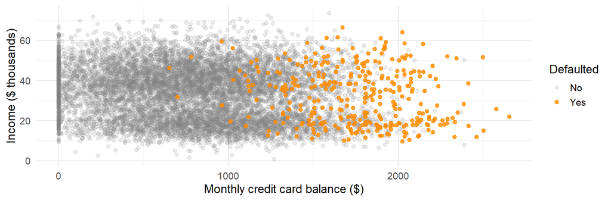

- 10,000 customers. Only 333 (3.3%) default.
- Defaulters carry **high balances**; income barely separates them.

## Why not linear regression?

> **Code Yes = 1 and No = 0, then fit a line. What goes wrong?**

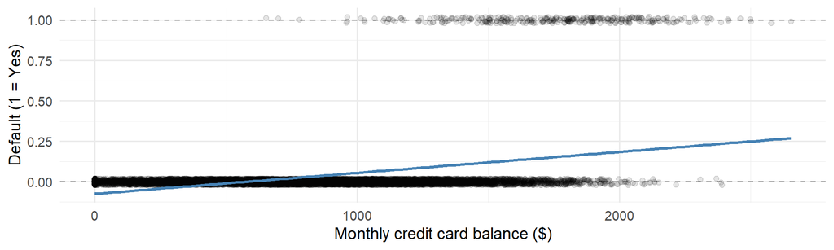

- Read the line as a probability of default, and it goes **negative** for 31% of customers.
- A probability has to stay between 0 and 1. We need a curve that does.

## 2. Scoring a classifier

## Error rate

> **On Day 9 we scored predictions with MSE. What replaces it?**

A class prediction is simply right or wrong. The **error rate** is the share we get wrong:

\[\text{Error rate} = \frac{1}{n}\sum_{i=1}^n I(y_i \neq \hat y_i)\]

- \(I(\cdot)\) is 1 when the prediction misses, 0 when it’s right.
- **Accuracy** = 1 − error rate.
- Day 9 carries over: the **training** error rate is optimistic. Judge a classifier on the **test** error rate.

## A classifier that ignores the data

> **How low an error rate can we get without looking at balance at all?**

**Always predict “No.”**

- It’s wrong only for the 333 defaulters: error rate 3.3%, accuracy 96.7%.
- It catches **zero** defaulters.
- Any real classifier has to beat this **baseline**: always predict the most common class.
- When one class is rare, a low error rate alone proves very little.

## A rule that uses balance

Predict **Yes** if balance > $2,000, otherwise **No**.

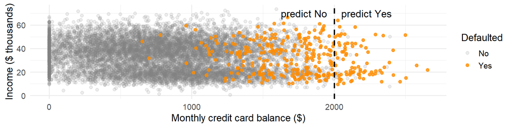

- We picked $2,000 **by eye** from the plot. No criterion chose it: the rule isn’t **optimizing** anything.
- Error rate: 2.8%, versus 3.3% for the baseline. Barely better? The error rate hides **which** mistakes each makes.

## The confusion matrix

Count the four possible outcomes. Call the class we’re looking for (default) **positive**.

|  | Predicted Yes | Predicted No |
| --- | --- | --- |
| **Actually Yes** | **True positive** (TP): defaulter caught | **False negative** (FN): defaulter missed |
| **Actually No** | **False positive** (FP): false alarm | **True negative** (TN): correctly cleared |

In R: `table(Actual = default, Predicted = pred)`.

## Baseline vs balance rule

> **Does the rule do anything the baseline can’t?**

| Classifier | TP | FN | FP | TN | Error rate |
| --- | --- | --- | --- | --- | --- |
| Always No | 0 | 333 | 0 | 9667 | 3.3% |
| Balance > $2,000 | 81 | 252 | 25 | 9642 | 2.8% |

- The rule catches 81 of 333 defaulters, at the cost of 25 false alarms.
- Both make few errors overall. Only the rule does what the bank needs.

## Three rates from the confusion matrix

Each answers a different question. All three are for the balance > $2,000 rule.

| Rate | Formula | It answers | Balance rule |
| --- | --- | --- | --- |
| **Recall** (sensitivity) | TP / (TP + FN) | Of the actual defaulters, what share did we catch? | 24.3% |
| **Precision** | TP / (TP + FP) | Of the customers we flagged, what share really defaulted? | 76.4% |
| **Specificity** | TN / (TN + FP) | Of the non-defaulters, what share did we clear? | 99.7% |

- The baseline’s recall is 0%. Its precision is undefined: it flags no one.
- High precision, low recall: the rule is right when it flags someone, but it misses most defaulters.

## Recall or precision?

> **For each one: which mistake is worse, a false positive or a false negative? So which rate matters more?**
1. A test that screens patients for cancer
2. An email spam filter
3. A bank deciding whether to approve a loan
4. A legal trial deciding whether the defendant is guilty

Talk it over with your neighbor.

## Recall or precision?

| Scenario | The worse mistake | Prioritize |
| --- | --- | --- |
| Cancer screening | **False negative**: a missed cancer goes untreated. A false alarm just means a follow-up test. | **Recall** |
| Spam filter | **False positive**: a real email (a job offer) lands in spam. A missed spam is a minor annoyance. | **Precision** |
| Bank approving loans | **False negative**: lending to someone who defaults loses the loan. Turning away someone who’d repay loses only some interest. | **Recall** |
| Legal trial | **False positive**: convicting an innocent person. “Innocent until proven guilty” says society sees this as worse than letting a guilty person go free. | **Precision** |

- Recall when **missing** a case is costly; precision when **false alarms** are costly.
- The cutoff is how you trade one for the other: “beyond a reasonable doubt” is a high cutoff (coming up).

## One number for both kinds of mistakes

> **Accuracy barely separates the baseline from the rule. Is there a single score that does?**

| Score | Formula | The idea | Always No | Balance rule |
| --- | --- | --- | --- | --- |
| **Accuracy** | (TP + TN) / *n* | Share of all predictions that are right | 96.7% | 97.2% |
| **Balanced accuracy** | (Recall + Specificity) / 2 | Accuracy within each class, averaged | 50.0% | 62.0% |
| **F1 score** | 2 · Precision · Recall / (Precision + Recall) | Combines precision and recall; 0 if either is 0 | 0.00 | 0.37 |

- **Balanced accuracy** counts both classes equally, however rare one is. The baseline drops to 50%: a coin flip.
- **F1** ignores the true negatives (the thousands of easy “No”s) and asks only how well we find the positives. The baseline scores 0.

## Where each score comes from

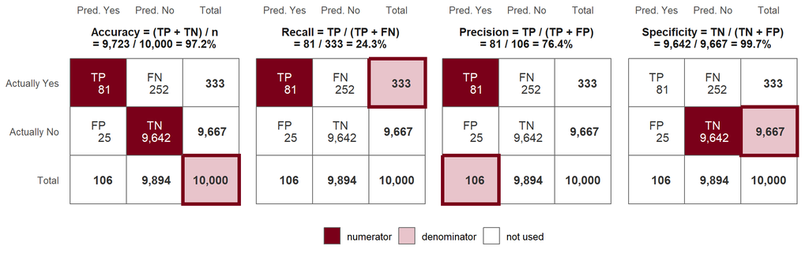

- **Balanced accuracy** = (Recall + Specificity) / 2 = (24.3% + 99.7%) / 2 = 62.0%. Accuracy weights each class by its size, so the 9,667 No’s dominate; balanced accuracy gives the Yes and No rows **equal weight**.
- **F1** = 2 · Precision · Recall / (Precision + Recall) = 0.37. Combines the **Yes row** and the **Yes column**; never uses TN.

## Moving the cutoff

> **What if the bank denies more loans?**

| Flag if balance > | Flagged | Recall | Precision | F1 | Error rate |
| --- | --- | --- | --- | --- | --- |
| $1,500 | 911 | 77.5% | 28.3% | 0.41 | 7.3% |
| $1,800 | 288 | 48.6% | 56.2% | 0.52 | 3.0% |
| $2,000 | 106 | 24.3% | 76.4% | 0.37 | 2.8% |

- A lower cutoff catches more defaulters, and raises more false alarms.
- The $2,000 cutoff has the lowest error rate, but F1 prefers $1,800. Different scores, different “best” cutoffs.
- **Which cutoff is right depends on what each mistake costs.** Lending to a defaulter can cost far more than turning away someone who’d have repaid.

## Summary

**Classification** predicts a category. Most classifiers estimate the probability of each class, then pick one.

- **Linear regression** on a 0/1 outcome gives “probabilities” below 0.
- **Error rate** replaces MSE. Compare it to the always-predict-the-majority **baseline**.
- The **confusion matrix** shows which mistakes a classifier makes: **recall**, **precision**, and **specificity** come from it.
- When one class is rare, use **balanced accuracy** or **F1**, not accuracy.
- Moving the **cutoff** trades missed cases for false alarms. Pick it by cost.

**Next time (Wed 10/21):** Our $2,000 rule was picked by eye and optimizes nothing; logistic regression chooses its coefficients by optimizing, and its probabilities stay between 0 and 1.

## For rest of class

- Work on the `day11_activity`
  - you’ll predict which orange juice shoppers buy from their brand loyalty, then pick a cutoff for a coupon campaign
- Ask me questions if you run into issues